# Assignment 2: Cross-Validation and K-Nearest-Neighbors

# The Data

```r
library(tidyverse)
library(tidymodels)
```

The dataset we will use for this assignment pertains to the [World Happiness Report](https://worldhappiness.report/). The following dataset contains information about six measurements of well-being in a country:

- The Gross Domestic Product (GDP) per capita *(dollars; log scale)*
- The life expectancy at birth of a healthy citizen *(years)*
- The social support of friends and family *(scale of 0-1, based on surveys)*
- The freedom to make life choices in the society *(scale of 0-1, based on surveys)*
- The generosity of the society *(scale of -1 to 1, based on surveys)*
- Perception of corruption in government of the country *(scale of 0-1, based on surveys)*

The data also records the year of measurement and the region of the country.

Although it is not a formal question on this assignment, you should begin by reading in the dataset and briefly exploring and summarizing the data, and by adjusting any variables that need cleaning.

```r
whr <- read_csv("https://www.dropbox.com/s/aau732ery3uujct/whr_clean.csv?dl=1")
whr <- whr %>%
  mutate(
    regional_indicator = factor(regional_indicator)
  )
```

# Part One: Happiness Scores

The World Happiness Report uses their own, privately-determined formula to combine the six measures of life quality into a “happiness score”. The dataset also contains this score, on a scale from 1 to 10.

*Hint: The following two questions require you to fit only one model each.*

#### Q1: Happiness over time

Is the happiness in the world changing linearly over time? Fit a simple linear model and interpret the results to address this question.

```r
lin_mod <- linear_reg() %>%
  set_mode("regression") %>%
  set_engine("lm")

whr_fit <- lin_mod %>%
  fit(happiness_score ~ year, data = whr)

whr_fit$fit %>% summary()
```

```
##
## Call:
## stats::lm(formula = happiness_score ~ year, data = data)
##
## Residuals:
##      Min       1Q   Median       3Q      Max
## -3.08688 -0.82376 -0.07919  0.81898  2.58985
##
## Coefficients:
##              Estimate Std. Error t value Pr(>|t|)
## (Intercept)  0.742196  13.180316   0.056    0.955
## year         0.002338   0.006548   0.357    0.721
##
## Residual standard error: 1.119 on 1852 degrees of freedom
## Multiple R-squared:  6.881e-05,  Adjusted R-squared:  -0.0004711
## F-statistic: 0.1274 on 1 and 1852 DF,  p-value: 0.7211
```

No, the model with only `year` as a predictor is not significant.

Was the happiness score approximately the same in all the years? Convert `year` to a factor variable, and fit a simple linear model to address this question.

```r
whr_fit_2 <- lin_mod %>%
  fit(happiness_score ~ factor(year), data = whr)

whr_fit_2$fit %>% summary()
```

```
##
## Call:
## stats::lm(formula = happiness_score ~ factor(year), data = data)
##
## Residuals:
##     Min      1Q  Median      3Q     Max
## -3.1959 -0.8274 -0.0821  0.7926  2.5525
##
## Coefficients:
##                  Estimate Std. Error t value Pr(>|t|)
## (Intercept)        6.4463     0.2145  30.058  < 2e-16 ***
## factor(year)2006  -1.2494     0.2448  -5.103 3.69e-07 ***
## factor(year)2007  -1.0280     0.2412  -4.262 2.13e-05 ***
## factor(year)2008  -1.0278     0.2393  -4.294 1.85e-05 ***
## factor(year)2009  -0.9886     0.2385  -4.145 3.55e-05 ***
## factor(year)2010  -0.9495     0.2367  -4.012 6.27e-05 ***
## factor(year)2011  -1.0222     0.2335  -4.379 1.26e-05 ***
## factor(year)2012  -1.0025     0.2340  -4.285 1.92e-05 ***
## factor(year)2013  -1.0517     0.2346  -4.482 7.85e-06 ***
## factor(year)2014  -1.0572     0.2336  -4.526 6.39e-06 ***
## factor(year)2015  -1.0422     0.2338  -4.457 8.81e-06 ***
## factor(year)2016  -1.0468     0.2340  -4.474 8.14e-06 ***
## factor(year)2017  -0.9859     0.2333  -4.225 2.50e-05 ***
## factor(year)2018  -0.9468     0.2340  -4.047 5.41e-05 ***
## factor(year)2019  -0.8754     0.2337  -3.746 0.000185 ***
## ---
## Signif. codes:  0 '***' 0.001 '**' 0.01 '*' 0.05 '.' 0.1 ' ' 1
##
## Residual standard error: 1.114 on 1839 degrees of freedom
## Multiple R-squared:  0.01602,    Adjusted R-squared:  0.008526
## F-statistic: 2.138 on 14 and 1839 DF,  p-value: 0.008156
```

Yes, the coefficients were significant for all the years, which suggests a different average happiness rating in each year as compared to the first year (2005)

#### Q2: Happiness Equation

How is each of the six measures of life quality weighted in calculating this score?  
Fit a model to estimate the weights, and interpret the coefficients. Which measures of life quality does the WHR consider to be most important to a country’s happiness?

*Hint: It is important to put all the metrics on the same scale first, since they are all in different units.*

```r
whr_rec <- recipe(happiness_score ~ log_gdp_per_capita + healthy_life_expectancy + social_support +
        freedom_to_make_life_choices + generosity + perceptions_of_corruption,
        data = whr) %>%
  step_normalize(all_numeric(), -happiness_score)

whr_wflow <- workflow() %>%
  add_recipe(whr_rec) %>%
  add_model(lin_mod)

whr_fit <- whr_wflow %>%
  fit(whr) %>%
  pull_workflow_fit()

whr_fit$fit %>%
  summary()
```

```
##
## Call:
## stats::lm(formula = ..y ~ ., data = data)
##
## Residuals:
##      Min       1Q   Median       3Q      Max
## -1.84731 -0.34108  0.02225  0.35670  1.92700
##
## Coefficients:
##                              Estimate Std. Error t value Pr(>|t|)
## (Intercept)                   5.45891    0.01419 384.721  < 2e-16 ***
## log_gdp_per_capita            0.41164    0.03133  13.138  < 2e-16 ***
## healthy_life_expectancy       0.22584    0.02745   8.229 3.84e-16 ***
## social_support                0.27478    0.02028  13.553  < 2e-16 ***
## freedom_to_make_life_choices  0.14924    0.01798   8.301  < 2e-16 ***
## generosity                    0.11824    0.01557   7.594 5.21e-14 ***
## perceptions_of_corruption    -0.11825    0.01722  -6.866 9.34e-12 ***
## ---
## Signif. codes:  0 '***' 0.001 '**' 0.01 '*' 0.05 '.' 0.1 ' ' 1
##
## Residual standard error: 0.5719 on 1624 degrees of freedom
##   (223 observations deleted due to missingness)
## Multiple R-squared:  0.7486, Adjusted R-squared:  0.7477
## F-statistic: 805.9 on 6 and 1624 DF,  p-value: < 2.2e-16
```

We first standardize all six variables, to make sure they are on the same scale regardless of how they are measured.

These six variables explain 74.86% of the variance in happiness scores; presumably the rest is changes to the WHR’s formula from year to year.

The GDP per capita was the most important metric (coeff = 0.41). Next were social support (0.275) and life expectancy (0.225), followed by freedom of choice (0.149), and last generosity and perception of corruption (both 0.118, with corruption being a detractor from happiness).

# Part Two: Predicting life expectancy (linear model)

Suppose we would like to know how various quality-of-life measurements impact a country’s life expectancy. We plan to use the other five metrics, as well as the region of the country, to try to predict the life expectancy.

Explore many possible candidate models. You should consider, within reason:

- Which variables should be included or omitted
- Possible interaction terms
- Polynomial terms of the variables (hint: you can use the function `step_poly(<variable name>, degree = 2)` to add polynomial terms in a `recipe`)
- *(optional)* Log-transformations or square root transformations of variables that appear skewed (Hint: You can use the functions `step_log()` or `step_sqrt()` in a `recipe`)

Of course, I do **not** expect you to try every possible combination of the above. Instead, you should come up with a reasonable approach that lets you eliminate many model options without trying every single one.

Do **not** include the code and results for every single candidate you try in the writeup for this assignment. Instead, supply the following:

#### Q1: Summary of approach

Write a short description (bullet points are fine) of your process in narrowing down your model.

How did you approach this problem, without spending hours upon hours fitting and cross-validating zillions of models?

*(Answers will vary)*

My approach is to visualize each variable against the response. For example, in the plots below, it appears that `perceptions_of_corruption` has a very weak relationship with life expectancy, but it might benefit from a polynomial transformation to spread the data out a bit. `social_support` appears to have a strong relationship with the response.

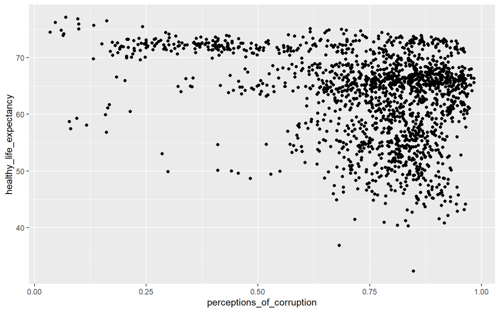

```r
whr %>%
  ggplot(aes(x = perceptions_of_corruption, y = healthy_life_expectancy)) +
  geom_point()
```

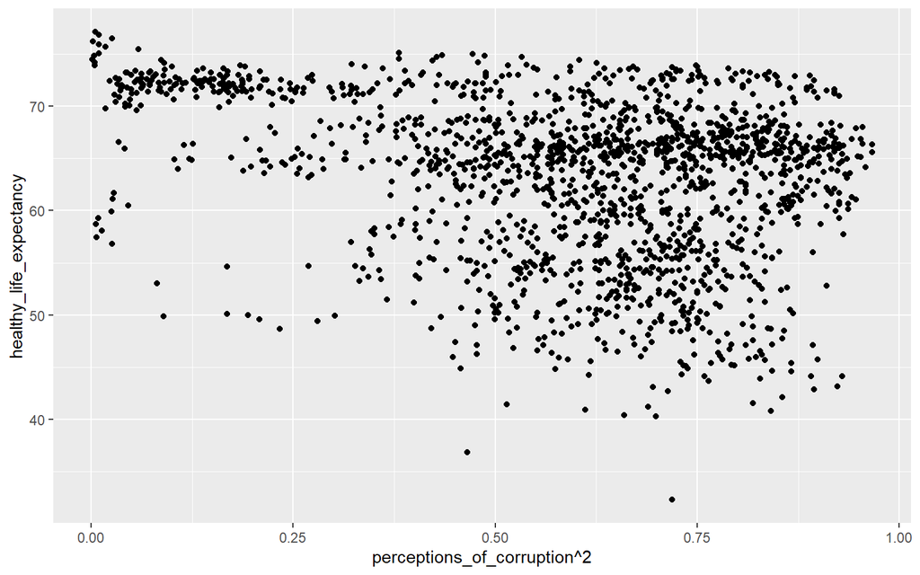

```r
whr %>%
  ggplot(aes(x = perceptions_of_corruption^2, y = healthy_life_expectancy)) +
  geom_point()
```

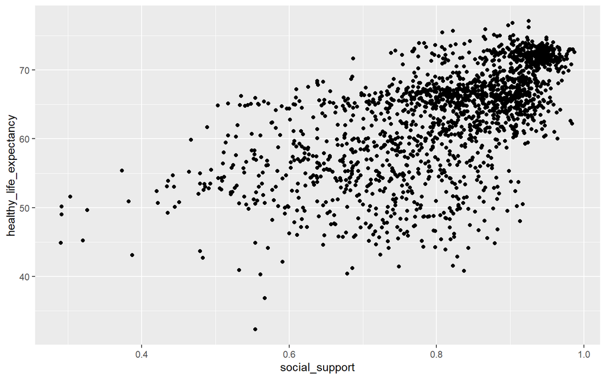

```r
whr %>%
  ggplot(aes(x = social_support, y = healthy_life_expectancy)) +
  geom_point()
```

I then add variables to the model one by one, checking the R-squared at each fit. When the R-squared changes hugely, I keep the variable. When it changes only a little, I use cross-validation to see if the improvement is overfitting or meaningful.

#### Q2: Three example candidates

Choose the three best candidate models among those you tried.

Supply your code and results for comparing these models, and discuss how you decided which *one* model was the best one.

```r
whr_cv <- vfold_cv(whr, v = 5)

whr_rec_1 <- recipe(healthy_life_expectancy ~
                      log_gdp_per_capita + social_support + freedom_to_make_life_choices +
                      year + perceptions_of_corruption,
                    data = whr)

whr_rec_2 <- whr_rec_1 %>%
  step_naomit(perceptions_of_corruption, skip = TRUE) %>%
  step_poly(perceptions_of_corruption, degree = 2)

whr_rec_3 <- recipe(healthy_life_expectancy ~
                      log_gdp_per_capita + social_support + freedom_to_make_life_choices +
                      year,
                    data = whr)

workflow() %>%
  add_model(lin_mod) %>%
  add_recipe(whr_rec_1) %>%
  fit_resamples(whr_cv) %>%
  collect_metrics()
```

```
## # A tibble: 2 x 6
##   .metric .estimator  mean     n std_err .config
##   <chr>   <chr>      <dbl> <int>   <dbl> <chr>
## 1 rmse    standard   3.82      5  0.0977 Preprocessor1_Model1
## 2 rsq     standard   0.753     5  0.0145 Preprocessor1_Model1
```

```r
workflow() %>%
  add_model(lin_mod) %>%
  add_recipe(whr_rec_2) %>%
  fit_resamples(whr_cv) %>%
  collect_metrics()
```

```
## # A tibble: 2 x 6
##   .metric .estimator  mean     n std_err .config
##   <chr>   <chr>      <dbl> <int>   <dbl> <chr>
## 1 rmse    standard   3.82      5  0.0975 Preprocessor1_Model1
## 2 rsq     standard   0.753     5  0.0145 Preprocessor1_Model1
```

```r
workflow() %>%
  add_model(lin_mod) %>%
  add_recipe(whr_rec_3) %>%
  fit_resamples(whr_cv) %>%
  collect_metrics()
```

```
## # A tibble: 2 x 6
##   .metric .estimator  mean     n std_err .config
##   <chr>   <chr>      <dbl> <int>   <dbl> <chr>
## 1 rmse    standard   3.88      5  0.0925 Preprocessor1_Model1
## 2 rsq     standard   0.737     5  0.0136 Preprocessor1_Model1
```

Based on the above, the best model is the one that **does** include perceptions of corruption. It’s almost exactly equal whether we square or not, so for simplicity, we’ll use the non-polynomial model.

#### Q3: Final model

Summarize the results from your final model. Don’t forget to fit your final model on the full dataset, even if you used *test/training* data or *cross-validation* during the model selection process.

Include a plot of the residuals and discussion of what you see, and interpretations of the coefficients and metrics.

```r
whr_final <- workflow() %>%
  add_model(lin_mod) %>%
  add_recipe(whr_rec_1) %>%
  fit(whr)

whr_final$fit %>% summary()
```

```
##         Length Class  Mode
## actions 1      -none- list
## fit     5      _lm    list
```

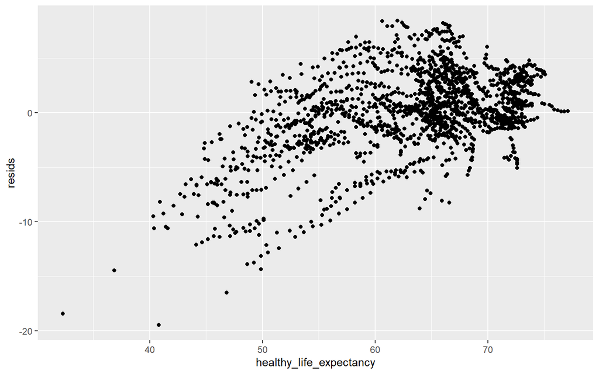

```r
whr %>%
  mutate(
    preds = predict(whr_final, whr)$.pred,
    resids = healthy_life_expectancy - preds
  ) %>%
  ggplot(aes(x = healthy_life_expectancy, y = resids)) +
  geom_point()
```

# Part Three: Predicting life expectancy (k-nearest-neighbors)

Now we will find the best KNN model for predicting life expectancy.

Consider only the three top candidate models from **Part Two**.

#### Q1: Tuning K

For **each** of your top three candidate models from Part Two, Q2, find the best choice of **K**. Show all your work, and provide a brief summary at the end.

```r
whr_clean <- whr %>%
  drop_na()

whr_cv_clean <- vfold_cv(whr_clean, v = 5)

knn_spec_tune <- nearest_neighbor(neighbors = tune()) %>%
  set_mode("regression") %>%
  set_engine("kknn")

k_grid <- grid_regular(neighbors(c(2, 20)),
                       levels = 5)

tune_1 <- workflow() %>%
  add_model(knn_spec_tune) %>%
  add_recipe(whr_rec_1) %>%
  tune_grid(
    resamples = whr_cv_clean,
    grid = k_grid
  ) %>%
  collect_metrics()
tune_1 %>% filter(.metric == "rmse") %>% arrange(.metric)
```

```
## # A tibble: 5 x 7
##   neighbors .metric .estimator  mean     n std_err .config
##       <int> <chr>   <chr>      <dbl> <int>   <dbl> <chr>
## 1         2 rmse    standard    4.21     5   0.106 Preprocessor1_Model1
## 2         6 rmse    standard    3.66     5   0.100 Preprocessor1_Model2
## 3        11 rmse    standard    3.57     5   0.110 Preprocessor1_Model3
## 4        15 rmse    standard    3.58     5   0.113 Preprocessor1_Model4
## 5        20 rmse    standard    3.60     5   0.115 Preprocessor1_Model5
```

```r
tune_1 %>% filter(.metric == "rsq") %>% arrange(desc(.metric))
```

```
## # A tibble: 5 x 7
##   neighbors .metric .estimator  mean     n std_err .config
##       <int> <chr>   <chr>      <dbl> <int>   <dbl> <chr>
## 1         2 rsq     standard   0.711     5 0.0126  Preprocessor1_Model1
## 2         6 rsq     standard   0.771     5 0.0103  Preprocessor1_Model2
## 3        11 rsq     standard   0.783     5 0.00929 Preprocessor1_Model3
## 4        15 rsq     standard   0.782     5 0.00924 Preprocessor1_Model4
## 5        20 rsq     standard   0.780     5 0.00885 Preprocessor1_Model5
```

```r
tune_2 <- workflow() %>%
  add_model(knn_spec_tune) %>%
  add_recipe(whr_rec_2) %>%
  tune_grid(
    resamples = whr_cv_clean,
    grid = k_grid
  ) %>%
  collect_metrics()

tune_2 %>% filter(.metric == "rmse") %>% arrange(.metric)
```

```
## # A tibble: 5 x 7
##   neighbors .metric .estimator  mean     n std_err .config
##       <int> <chr>   <chr>      <dbl> <int>   <dbl> <chr>
## 1         2 rmse    standard    4.22     5  0.0610 Preprocessor1_Model1
## 2         6 rmse    standard    3.71     5  0.103  Preprocessor1_Model2
## 3        11 rmse    standard    3.62     5  0.119  Preprocessor1_Model3
## 4        15 rmse    standard    3.61     5  0.125  Preprocessor1_Model4
## 5        20 rmse    standard    3.63     5  0.127  Preprocessor1_Model5
```

```r
tune_2 %>% filter(.metric == "rsq") %>% arrange(desc(.metric))
```

```
## # A tibble: 5 x 7
##   neighbors .metric .estimator  mean     n std_err .config
##       <int> <chr>   <chr>      <dbl> <int>   <dbl> <chr>
## 1         2 rsq     standard   0.708     5 0.00918 Preprocessor1_Model1
## 2         6 rsq     standard   0.766     5 0.00786 Preprocessor1_Model2
## 3        11 rsq     standard   0.777     5 0.00884 Preprocessor1_Model3
## 4        15 rsq     standard   0.778     5 0.00928 Preprocessor1_Model4
## 5        20 rsq     standard   0.776     5 0.00926 Preprocessor1_Model5
```

```r
tune_3 <- workflow() %>%
  add_model(knn_spec_tune) %>%
  add_recipe(whr_rec_3) %>%
  tune_grid(
    resamples = whr_cv_clean,
    grid = k_grid
  ) %>%
  collect_metrics()

tune_3 %>% filter(.metric == "rmse") %>% arrange(.metric)
```

```
## # A tibble: 5 x 7
##   neighbors .metric .estimator  mean     n std_err .config
##       <int> <chr>   <chr>      <dbl> <int>   <dbl> <chr>
## 1         2 rmse    standard    4.27     5  0.0708 Preprocessor1_Model1
## 2         6 rmse    standard    3.76     5  0.0594 Preprocessor1_Model2
## 3        11 rmse    standard    3.67     5  0.0883 Preprocessor1_Model3
## 4        15 rmse    standard    3.66     5  0.0927 Preprocessor1_Model4
## 5        20 rmse    standard    3.67     5  0.0983 Preprocessor1_Model5
```

```r
tune_3 %>% filter(.metric == "rsq") %>% arrange(desc(.metric))
```

```
## # A tibble: 5 x 7
##   neighbors .metric .estimator  mean     n std_err .config
##       <int> <chr>   <chr>      <dbl> <int>   <dbl> <chr>
## 1         2 rsq     standard   0.699     5 0.0145  Preprocessor1_Model1
## 2         6 rsq     standard   0.758     5 0.00950 Preprocessor1_Model2
## 3        11 rsq     standard   0.770     5 0.00778 Preprocessor1_Model3
## 4        15 rsq     standard   0.771     5 0.00741 Preprocessor1_Model4
## 5        20 rsq     standard   0.771     5 0.00738 Preprocessor1_Model5
```

Model 3: Lowest rmse and highest r-squared occurs at k = 15.

Among these three, Model 1 again has the best performance.

#### Q2: Best model

Fit and report your single best model from Q1.

You should include:

- An argument for your choice of K, including a plot.
- A plot of the residuals

```r
k_grid_finer <- grid_regular(neighbors(c(12, 19)),
                       levels = 7)

tune_final <- workflow() %>%
  add_model(knn_spec_tune) %>%
  add_recipe(whr_rec_1) %>%
  tune_grid(
    resamples = whr_cv_clean,
    grid = k_grid_finer
  ) %>%
  collect_metrics()

tune_final %>% filter(.metric == "rmse") %>% arrange(.metric)
```

```
## # A tibble: 7 x 7
##   neighbors .metric .estimator  mean     n std_err .config
##       <int> <chr>   <chr>      <dbl> <int>   <dbl> <chr>
## 1        12 rmse    standard    3.57     5   0.111 Preprocessor1_Model1
## 2        13 rmse    standard    3.57     5   0.112 Preprocessor1_Model2
## 3        14 rmse    standard    3.57     5   0.113 Preprocessor1_Model3
## 4        15 rmse    standard    3.58     5   0.113 Preprocessor1_Model4
## 5        16 rmse    standard    3.58     5   0.114 Preprocessor1_Model5
## 6        17 rmse    standard    3.59     5   0.114 Preprocessor1_Model6
## 7        19 rmse    standard    3.59     5   0.115 Preprocessor1_Model7
```

```r
tune_final %>% filter(.metric == "rsq") %>% arrange(desc(.metric))
```

```
## # A tibble: 7 x 7
##   neighbors .metric .estimator  mean     n std_err .config
##       <int> <chr>   <chr>      <dbl> <int>   <dbl> <chr>
## 1        12 rsq     standard   0.783     5 0.00937 Preprocessor1_Model1
## 2        13 rsq     standard   0.782     5 0.00938 Preprocessor1_Model2
## 3        14 rsq     standard   0.782     5 0.00931 Preprocessor1_Model3
## 4        15 rsq     standard   0.782     5 0.00924 Preprocessor1_Model4
## 5        16 rsq     standard   0.782     5 0.00917 Preprocessor1_Model5
## 6        17 rsq     standard   0.781     5 0.00909 Preprocessor1_Model6
## 7        19 rsq     standard   0.780     5 0.00891 Preprocessor1_Model7
```

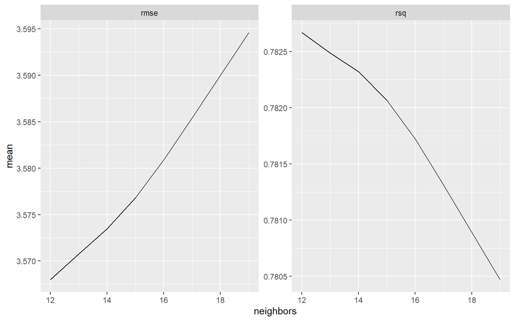

```r
tune_final %>%
  ggplot(aes(x = neighbors, y = mean)) +
  geom_line() +
  facet_wrap(~.metric, scales = "free")
```

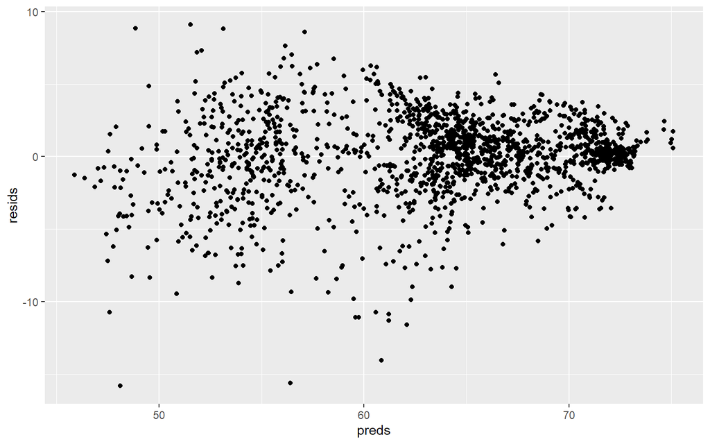

```r
knn_spec <- nearest_neighbor(neighbors = 14) %>%
  set_mode("regression") %>%
  set_engine("kknn")

final_knn <- workflow() %>%
  add_model(knn_spec) %>%
  add_recipe(whr_rec_1) %>%
  fit(whr_clean)

whr_clean %>%
  mutate(
    preds = predict(final_knn, whr_clean)$.pred,
    resids = healthy_life_expectancy - preds
  ) %>%
  ggplot(aes(x = preds, y = resids)) +
  geom_point()
```

These residuals looks pretty good! They are around 0 and not strongly patterned.

(If we want to get fancy, there’s some concern about heteroskedacisity, but this only matters in linear models.)

#### Q3: Different distance metrics

Using the same predictors you chose in Q2, find the best choice of $K$ for a KNN model using absolute distance. How does this model compare to the one from Q2? Conceptually, why would you get a different answer using these two different distance metrics?

```r
knn_spec_tune_m <- nearest_neighbor(neighbors = tune(), dist_power = 1) %>%
  set_mode("regression") %>%
  set_engine("kknn")

tune_m <- workflow() %>%
  add_model(knn_spec_tune_m) %>%
  add_recipe(whr_rec_1) %>%
  tune_grid(
    resamples = whr_cv_clean,
    grid = k_grid_finer
  ) %>%
  collect_metrics()

tune_m %>% filter(.metric == "rmse") %>% arrange(.metric)
```

```
## # A tibble: 7 x 7
##   neighbors .metric .estimator  mean     n std_err .config
##       <int> <chr>   <chr>      <dbl> <int>   <dbl> <chr>
## 1        12 rmse    standard    3.53     5   0.102 Preprocessor1_Model1
## 2        13 rmse    standard    3.53     5   0.104 Preprocessor1_Model2
## 3        14 rmse    standard    3.53     5   0.106 Preprocessor1_Model3
## 4        15 rmse    standard    3.53     5   0.109 Preprocessor1_Model4
## 5        16 rmse    standard    3.53     5   0.111 Preprocessor1_Model5
## 6        17 rmse    standard    3.54     5   0.113 Preprocessor1_Model6
## 7        19 rmse    standard    3.55     5   0.116 Preprocessor1_Model7
```

```r
tune_m %>% filter(.metric == "rsq") %>% arrange(desc(.metric))
```

```
## # A tibble: 7 x 7
##   neighbors .metric .estimator  mean     n std_err .config
##       <int> <chr>   <chr>      <dbl> <int>   <dbl> <chr>
## 1        12 rsq     standard   0.787     5 0.00889 Preprocessor1_Model1
## 2        13 rsq     standard   0.788     5 0.00894 Preprocessor1_Model2
## 3        14 rsq     standard   0.788     5 0.00901 Preprocessor1_Model3
## 4        15 rsq     standard   0.788     5 0.00912 Preprocessor1_Model4
## 5        16 rsq     standard   0.787     5 0.00922 Preprocessor1_Model5
## 6        17 rsq     standard   0.787     5 0.00931 Preprocessor1_Model6
## 7        19 rsq     standard   0.786     5 0.00940 Preprocessor1_Model7
```

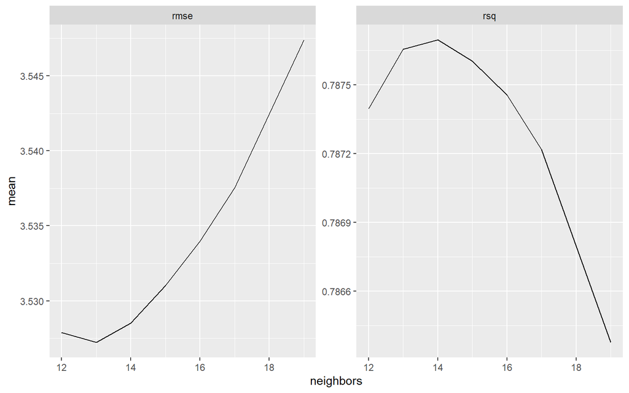

```r
tune_m %>%
  ggplot(aes(x = neighbors, y = mean)) +
  geom_line() +
  facet_wrap(~.metric, scales = "free")
```

K = 14 is still looking good.

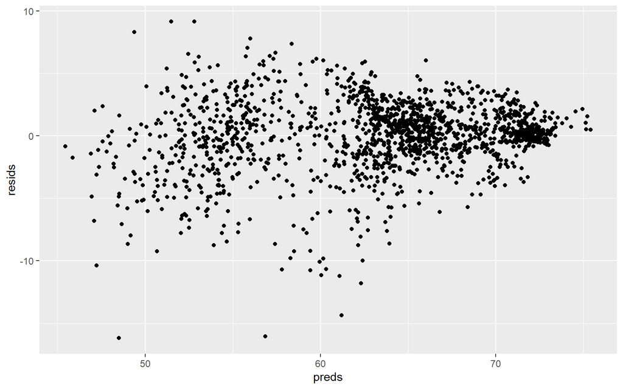

```r
knn_spec_m <- nearest_neighbor(neighbors = 14, dist = 1) %>%
  set_mode("regression") %>%
  set_engine("kknn")

final_knn_m <- workflow() %>%
  add_model(knn_spec_m) %>%
  add_recipe(whr_rec_1) %>%
  fit(whr_clean)

whr_clean %>%
  mutate(
    preds = predict(final_knn_m, whr_clean)$.pred,
    resids = healthy_life_expectancy - preds
  ) %>%
  ggplot(aes(x = preds, y = resids)) +
  geom_point()
```

# Part Four: Predicting on new data

The following code will load up a dataset of the World Happiness Report from 2021, pertaining to happiness measurements in the year 2020.

```r
whr_new <- read_csv("https://www.dropbox.com/s/h4kgksgawui3n5z/whr_2020.csv?dl=1")
```

Use your **one** best *least-squares regression* model to predict the life expectancy of all countries.

```r
final_mod_ls <- workflow() %>%
  add_model(lin_mod) %>%
  add_recipe(whr_rec_1) %>%
  fit(whr)

whr_new <- whr_new %>%
  mutate(
    preds_ls = predict(final_mod_ls, whr_new)$.pred
  )
```

Use your **one** best *KNN* model to predict the life expectancy of all countries.

```r
final_mod_knn <- workflow() %>%
  add_model(knn_spec_m) %>%
  add_recipe(whr_rec_1) %>%
  fit(whr)

whr_new <- whr_new %>%
  mutate(
    preds_knn = predict(final_mod_knn, whr_new)$.pred
  )

whr_new %>%
  rmse(
    truth = healthy_life_expectancy,
    estimate = preds_ls
  )
```

```
## # A tibble: 1 x 3
##   .metric .estimator .estimate
##   <chr>   <chr>          <dbl>
## 1 rmse    standard        3.46
```

```r
whr_new %>%
  rmse(
    truth = healthy_life_expectancy,
    estimate = preds_knn
  )
```

```
## # A tibble: 1 x 3
##   .metric .estimator .estimate
##   <chr>   <chr>          <dbl>
## 1 rmse    standard        2.48
```

Which model did a better job predicting the true values in the new data?

The KNN model with absolute distance and K = 14 was the overall winner!

(We sometimes call this new data - that was not involved in the **cross-validation** process or in the final model fitting - the **validation** set. It is the “Ultimate” test set, that only gets to be used once ever.)

# Part Five: Discussion Questions

For these questions, you do **not** have to actually perform any of the computations described. However, if the conceptual answer is not obvious to you, it may help to do so!

#### Q1: Parametric and Non-Parametric

Make an argument for why a **parametric** method, like least-squares regression, might be preferred in this task.

If we are trying to understand what factors drive a country’s life expectancy, so that we can implement policy to improve well-being, the parametric model will be better. We’ll be able to interpret the coefficients as measures of the relationship between predictors and response.

Then make an argument for why a **non-parametric** method, like K-Nearest-Neighbors, might be preferred.

If we are trying to use current information to accurately predict the life expectancy next year in a particular country, it may be that a non-parametric method performs better.

#### Q2: Interpretation and Prediction

If your only goal were **interpretation**, which of the candidate models (from *any* section of the assignment) would you have chosen? Why?

I would choose the linear model without the polynomial term, because transformed variables are harder to interpret and parametric methods are better for interpretation.

If your only goal were **prediction** on future data, which of the candidate models would you have chosen? Why?

In this case, I would choose KNN with K = 14, since it had the lowest MSE on the validation set and in cross-validation studies.

#### Q3: Standardization

Consider your final best least-squares regression model from Part Two, Q3. Suppose we fit this model again, but this time, we normalize **all** of the quantitative variables.

Will anything change? Give a (conceptual) argument for why this is true.

The coefficients will change, because when you normalize, you change the scale of the values of the predictors.

However, the significance of the coefficients and the performance of the model will not change, because you are not meaningfully changing the model assumptions in any way.

#### Q4: Standardization II

Consider your final best KNN model from Part Three, Q3. Suppose we fit this model again, but this time, we normalize **all** of the quantitative variables.

Will anything change? Give a (conceptual) argument for why this is true.

Absolutely!

(In fact, ideally we should have normalized all the quantitative variables from the start.)

KNN is based on distances between observations. If we do not normalize, variables measured on a large scale will weigh more heavily in the calculation. Normalizing all the variables evens the playing field and changes the model assumptions, so the model performance will be different.

#### Q5: Quantitative or Categorical?

In Part One, Q1, you discovered that (spoiler alert!) the `year` variable did **not** have a linear relationship with the `happiness_score`, but that when we treated `year` as categorical, it did have some relationship.

Suppose we add the predictor `year` to our final model as a **categorical variable** and fit the model on all the data. Then, we use this new model to predict on the 2020 data.

What is wrong with this plan?

If “year” is a categorical variable, we expect future data to be limited to the known categories. But 2020 is not a category in the data up through 2019!